# Análisis de los factores involucrados y relaciones en el proceso de aprendizaje de inglés de los estudiantes de UTEC durante el periodo académico 2023-1.

## Datos previos

**Objetivos**

- Analizar las variables involucradas en el aprendizaje del inglés de los estudiantes de UTEC en el periodo 2023-1.
- Identificar las dificultades, factores y circunstancias que enfrentan los estudiantes de UTEC y su relación con el aprendizaje del inglés durante el periodo 2023-1 en distintas instituciones que enseñan el inglés.
- Informar al Centro de Idiomas Conversa Academics sobre los resultados académicos, incluyendo evaluaciones y nivel de competencia del idioma, que atraviesan sus estudiantes en comparación con otros centros de idiomas de inglés.

**Población, muestra y muestreo**

- Población : Estudiantes de UTEC
- Muestra : 163 Estudiantes de UTEC que respondieron la encuesta
- Muestreo : Muestreo por conveniencia.

Variables

| Variables | Tipo | Restricción |
| --- | --- | --- |
| `Créditosacadémicos (Creditos)` | Numérica → Discreta | Números enteros mayor o igual a 12 y menor igual a 26. |
| `Número de cursos (NumCursos)` | Numérica → Discreta | Números enteros positivos enteros mayor o igual a 3 y menor o igual que 9 cursos. |
| `Promedio ponderado de exámenes de inglés (Promedio_Ingles)` | Numérica → Discreta | Números positivos mayor igual a 0 y menor o igual a 20. |
| `Estado emocional (Nivel_Estres)` | Categórica → Ordinal | Nivel de estado emocional en una escala del 1 al 5. |
| `Nivel de competencia (Nivel_Competencia)` | Categórica → Nominal | Básico, Intermedio o Avanzado . |
| `Número de meses estudiando (Meses_Estudio)` | Numérica → Discreta | Números enteros mayor o igual a 1, en el caso que hayan respondido que sí estudiaron en un centro de idiomas, caso contrario es considerado NA. |
| `Cantidad de horas dedicadas en el estudio de ingles a la semana (Horas_Estudio)` | Categórica → Nominal | Rangos de horas: “0 h”, “1 a 2h”,“3 a 4h”, “más de 4h”, en el caso que hayan respondido que sí estudiaron en un centro de idiomas, caso contrario es considerado NA. |

```
## [1] Intermedio Básico     Intermedio Básico     Básico     Intermedio
## Levels: Básico < Intermedio < Avanzado
```

Nivel de Competencia por Instituto

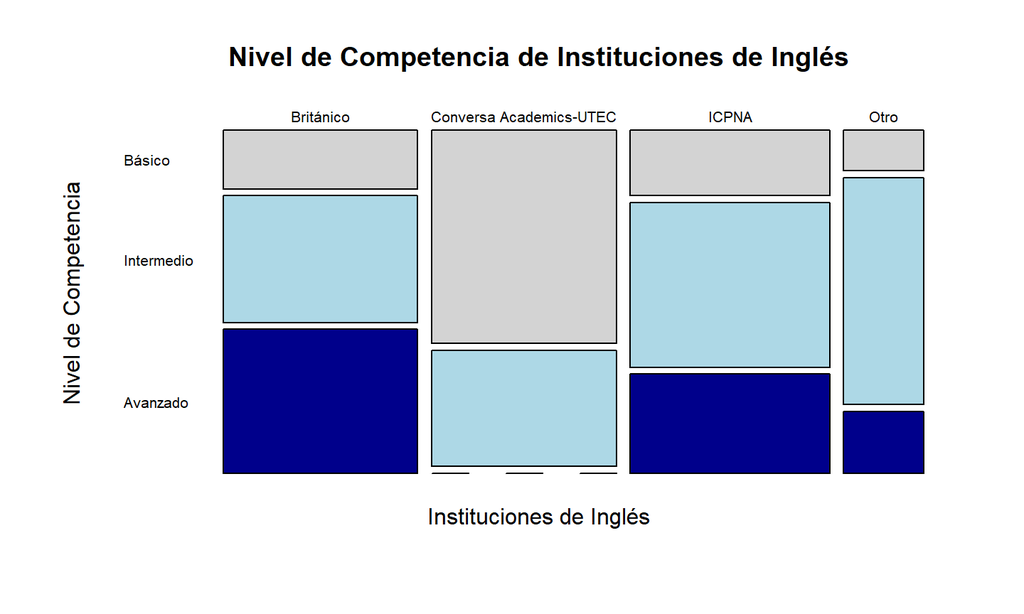

En nuestra muestra, el Instituto `Conversa Academics(UTEC)` tiene mas del 50% de sus estudiantes en el nivel Básico. Esto contrasta con los institutos `ICPNA` y `Británico` cuya mayoría de estudiantes se encuentra en Intermedio o Avanzado. Además, en nuestra muestra, Conversa no tiene estudiantes en nivel Avanzado.

Promedio de inglés ante nivel de competencia

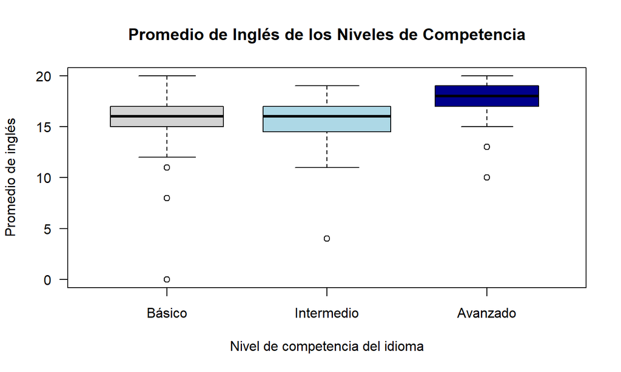

La gráfica sugiere que al menos el 75% (aproximadamente) de los estudiantes de nivel Avanzado poseen un promedio mayor o igual por lo menos el 75% (aproximadamente) de los estudiantes de nivel básico e intermedio.

Nivel de Estrés contra Créditos

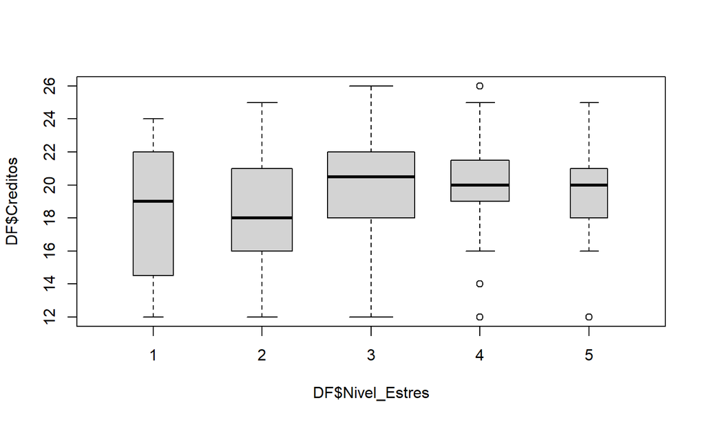

Si vemos solo los valores `3` , `4` y `5` de la variable `Nivel de Estres` por separado no encontramos una relación clara entre `Créditos` y `Nivel de Estres`. Por ello, a pesar de que al analizar los valores `1` y `2` de la variable `Nivel de Estres` podamos ver alguna relación, podríamos conseguir eventos independientes en base a estas dos variables

## Probabilidad Empírica-Nivel de Competencia

Gráfica 1:

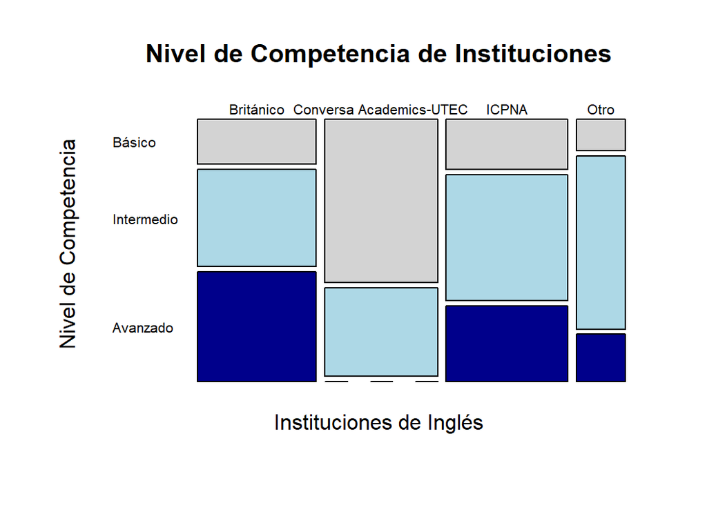

Gráfica 2:

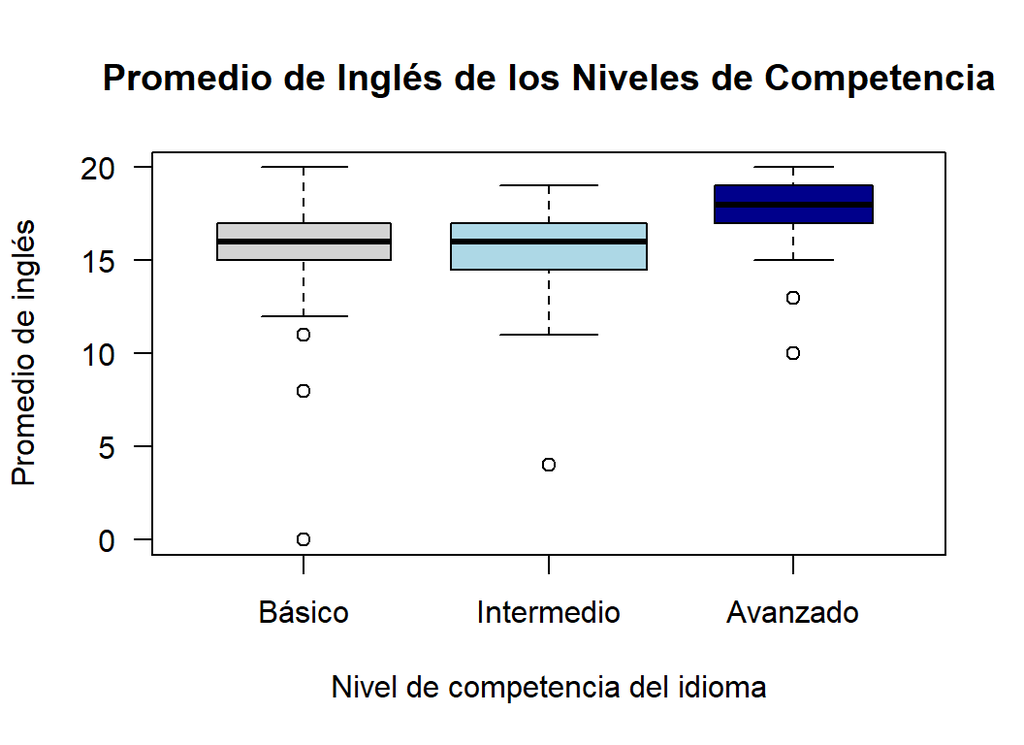

## Datos para el experimento 1

**Espacio de Resultados**

Se definen los eventos atómicos: El estudiante tiene nivel Básico, El estudiante tiene nivel Intermedio y el estudiante tiene nivel Avanzado.

\[\Omega_{1} = \{Básico , Intermedio , Avanzado , Indefinido\}\]

\[F_{1} = 2^{|\Omega_{1}|} = 16\]

**Cálculo de las probabilidades de los eventos atómicos**

```
##
##   Avanzado     Básico Indefinido Intermedio
##       0.26       0.31       0.04       0.39
```

Se verifica que la suma de las probabilidades de los eventos atómicos de 1.

\[ \sum\mathbb{P}(Ea) = 1 \]

```r
sum(round(prop.table(table(DF$Nivel_Comp)), 2))
```

```
## [1] 1
```

## Datos para el experimento 2

#### Espacio de Resultados

Los eventos atómicos para este experimento aleatorio son: El estudiante tiene el nivel 1, El estudiante tiene el nivel 2, el estudiante tiene el nivel 3, el estudiante tiene el nivel 4, El estudiante tiene el nivel 5.

\[\Omega_{2} = \{ 1 , 2 , 3 , 4 , 5\}\]

\[ {F}\_{2} = 2 ^ {\|\Omega{2}\|} = 32 \]

```
##
##  1  2  3  4  5
## 15 34 70 31 13
```

```
##
##    1    2    3    4    5
## 0.09 0.21 0.43 0.19 0.08
```

Se verifica que la suma de las probabilidades de los eventos atómicos de 1.

\[ \sum\mathbb{P}(Ea) = 1 \]

```
## [1] 1
```

## Experimento aleatorio 1 Y 2

`E1` : Escojo un estudiante de UTEC y observo el `Nivel de Compentencia` de idioma Inglés.

\[\mathbb{P}(Básico) = 0.31 \\ \mathbb{P}(Intermedio) = 0.39 \\ \mathbb{P}(Avanzado) = 0.26 \\ \mathbb{P}(Indefinido) = 0.04\]

Al escoger al azar un alumno de UTEC es más probable que sea del `Nivel Intermedio`.

`E2` : Escojo al azar un estudiante de UTEC y observo el `Nivel de Estres` que poseen en una escala del 1 al 5. Donde: 1 significa que tiene un nivel de estrés bajo y 5 significa que tiene un nivel de estrés alto.

\[\mathbb{P}(1) = 0.09 \\ \mathbb{P}(2) = 0.21 \\ \mathbb{P}(3) = 0.43 \\ \mathbb{P}(4) = 0.19 \\ \mathbb{P}(5) = 0.08\]

Si escojo al azar un alumno de UTEC lo más probable es que tenga un nivel de estrés medio (3 en la escala del 1 al 5).

## Eventos Dependientes e Independientes

Usaremos el siguiente criterio para determinar la independencia de dos Eventos.

\[|\mathbb{P}(AB) - \mathbb{P}(A)*\mathbb{P}(B)| < 0.01\]

Inicialmente, intuimos que un estudiante tenga un determinado `Nivel de Competencia` y pertenezca a una determinada `Institución` no deberían estar relacionados.

**Experimento 3**: Escoger al azar un alumno de UTEC y anotamos su `Nivel de Competencia` y su `Institución`

`Evento A` : Que el alumno sea de nivel Básico

`Evento B` : Que el alumno sea del ICPNA

```
##
##              Británico Conversa Academics-UTEC ICPNA Otro Sin INS Sum
##   Avanzado          17                       0    12    3      10  42
##   Básico             7                      24     8    2       9  50
##   Indefinido         0                       0     0    3       4   7
##   Intermedio        15                      13    20   11       5  64
##   Sum               39                      37    40   19      28 163
```

```r
abs(PA*PB-PAB) < 0.01
```

```
## [1] FALSE
```

Teorema de Bayes en el experimento 3

Calculamos la \(\mathbb{P}(A\|B)\) con Bayes:

```r
(ProbBdadoA*PA)/PB
```

```
## [1] 0.2
```

```r
PA
```

```
## [1] 0.3067485
```

Probabilidad Total

Calcularemos la probabilidad B con la formula de probabilidad total

```r
PB
```

```
## [1] 0.2453988
```

```r
PA
```

```
## [1] 0.3067485
```

```r
ProbBdadoA
```

```
## [1] 0.16
```

```r
PAc <- 1 - PA
ProbBdadoAc <- 32/113

PA*ProbBdadoA + PAc*ProbBdadoAc
```

```
## [1] 0.2453988
```

## Eventos independientes

Grafica1:

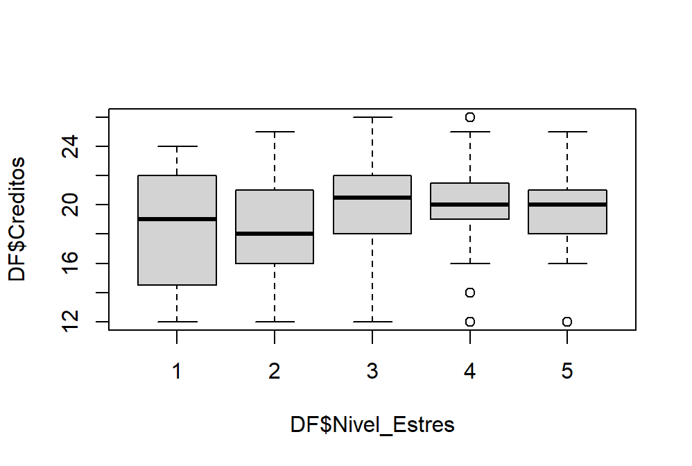

````
Aplicando addmargins con Créditos<15 y Nivel de estrés


```
##
##           1   2   3   4   5 Sum
##   FALSE  11  29  66  27  12 145
##   TRUE    4   5   4   4   1  18
##   Sum    15  34  70  31  13 163
```


```r
PE <- 13/163
PF <- 145/163
PEF  <-12/163
```
````

`Evento_E`: Que el alumno tenga un nivel de estrés 5 (alto)

`Evento_F` : Que el alumno esté llevando un número de créditos académicos mayor o igual a 15

```r
abs(PE*PF - PEF)  < 0.01
```

```
## [1] TRUE
```

```
## [1] 0.08275862
```

```
## [1] 0.0797546
```

\(\mathbb{P}(E|F)\) es similar a \(\mathbb{P}(E)\)

Utilizando Teorema de Bayes

Calculamos la \(\mathbb{P}(E|F)\) con Bayes:

```r
ProbEdadoF
```

```
## [1] 0.08275862
```

```r
ProbFdadoE <- 12/13
(ProbFdadoE*PE)/PF
```

```
## [1] 0.08275862
```

```r
PE
```

```
## [1] 0.0797546
```

Notamos que la \(\mathbb{P}(E|F)\) es similar a la \(\mathbb{P}(E)\), se evidencia una vez más que son aproximadamente independientes

## Variables Discretas - Meses de Estudio

Veamos el histograma de esta variable

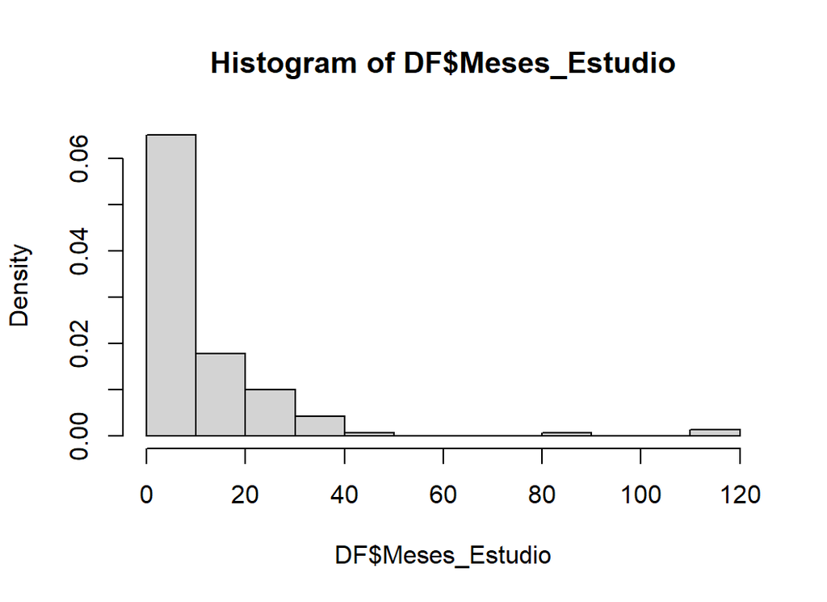

Notamos que tenemos datos por encima de los 36 meses que es el tiempo máximo de la duración de los principales programas de inglés. Por ello, estudiaremos a los alumnos que están entre 1 y 36 meses de estudio.

```
Grafica 2
```

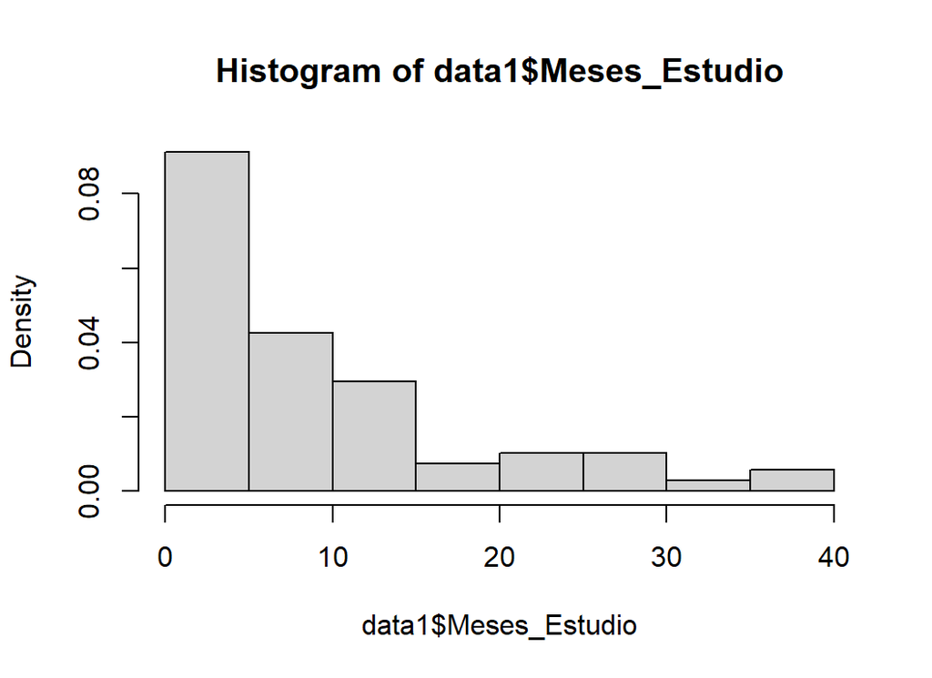

##### El histograma sugiere que podría asemejarse a un distribución `Geométrica`.

## Media varianza y “p”

Calculamos el parámetro `p` en base al valor esperado (Media).

```r
media <- mean(data1$Meses_Estudio)
```

```
## [1] 9.683824
```

```r
p <- 1/media
```

```
## [1] 0.103265
```

```r
var  <- var(data1$Meses_Estudio)
```

```
## [1] 85.403
```

```r
Varx <- (1 -p)/(p*p)
```

```
## [1] 84.09261
```

```
Gráfica 2
```

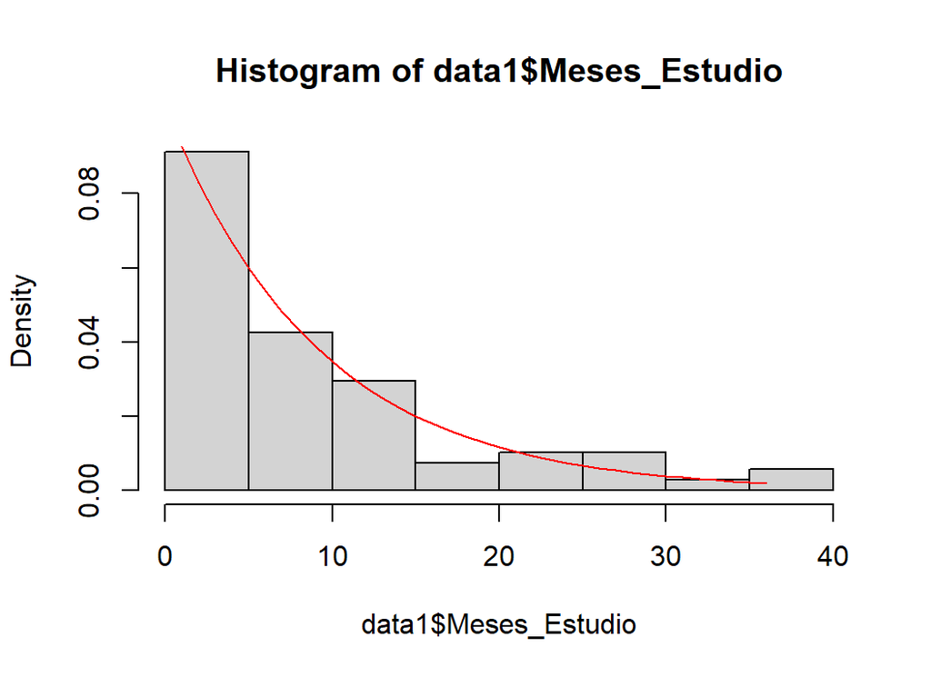

##### La gráfica sugiere que podría haber una similitud con la Distribución `Geométrica`. Sin embargo, no existe un experimento subyacente que pueda validar que esta similitud tenga sentido. No hay un éxito asociado a los valores de esta variable. Además, la variable `Meses de Estudio` no cuenta un número de intentos hasta la ocurrencia del primer éxito.

## Variable Número de Cursos

Gráfica 1

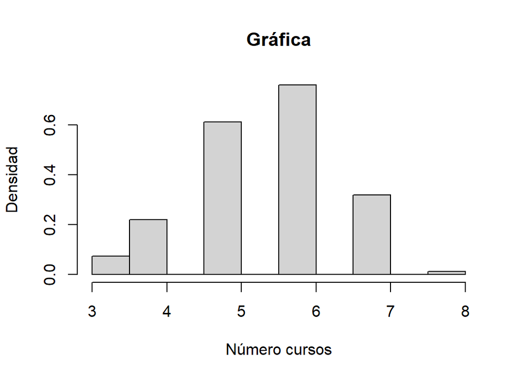

El histograma sugiere que podría ser semejante a una distribución `binomial`. Se procede a calcular sus parámetros

```
## [1] 5.53
```

```
## [1] 1.05
```

```
## [1] 0.8101266
```

```
## [1] 7
```

```
Usamos la función `rbinom` para realizar un histograma y compararlo con el de la variable `Numero de Cursos`
```

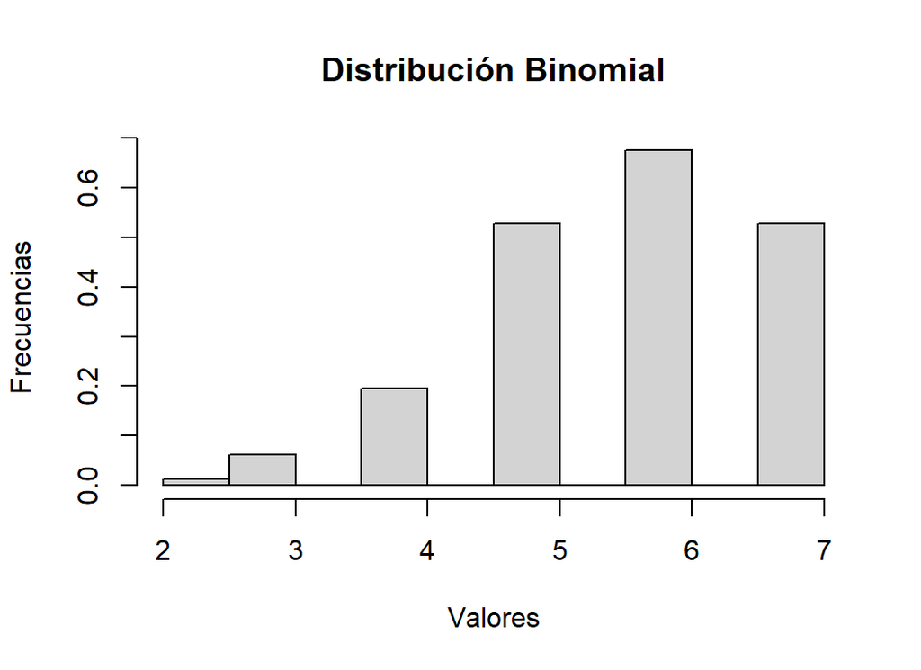